# Introducción al R

MSc. Alvaro Chirino

Noviembre, 2024

# Introducción a R

## ¿Qué es R?

[figure not shown]

Comparación perfecta

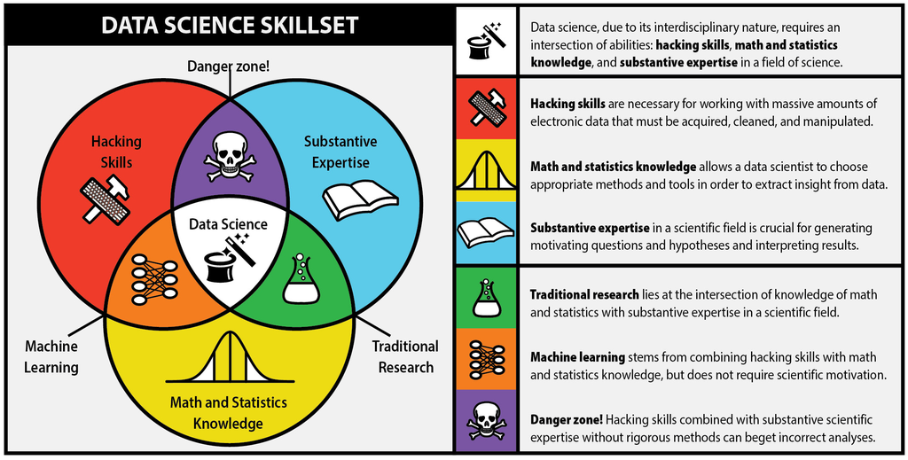

Ciencia de datos

### Algo de historia de R

- R es el hermano de S
- S es un lenguaje de programación estadística desarrollado por John Chambers de Bell Labs
- El objetivo de S era “convertir las ideas en el software, de forma rápida y fielmente”
- S fue creado en 1976 y se reinvento 1988 introduciendo muchos cambios
- En 1993, StatSci (fabricante de S-Plus) adquieren licencia exclusiva a S
- S-Plus integra S con una interfaz gráfica de usuario agradable y pleno apoyo al cliente
- R Fue creado por Ross Ihaka y Robert Gentleman de la University of Auckland, New Zealand

### Acerca de R

- El proyecto R inicio en 1991
- R apareció por primera vez en 1996 como un software de código abierto!
- Altamente personalizable a través de paquetes
- La comunidad R, se basa en el poder de la colaboración con miles de paquetes de libre disposición
- Existen muchas interfaces gráficas de usuario de R libres y comerciales (por ejemplo R Studio y Revolución)

### ¿Qué es R?

R es un conjunto integrado de servicios de software para la manipulación de datos, cálculo y representación gráfica. Incluye:

- instalación sencilla y un fácil almacenamiento de datos
- un conjunto de operadores para los cálculos en arrays, particularmente en las matrices
- facilidad en los gráficos y el análisis de datos y
- bien desarrollado, lenguaje de programación sencillo y eficaz que incluye condicionales, bucles, funciones recursivas definidos por el usuario.
- Altamente intuitivo

> A pesar de ser libre y de código abierto, R es ampliamente utilizado por los analistas de datos dentro de las empresas y el mundo académico. (R en the NY Times) Ver [NY Times](https://www.nytimes.com/2009/01/07/technology/business-computing/07program.html?pagewanted=all&_r=0) artículo.

### Algunas referencias

- https://cran.r-project.org/

## RStudio

RStudio es un ambiente libre y abierto de desarrollo de código integrado.

- multiplataforma
- El resaltado de sintaxis, completado de código, y la sangría inteligente
- gestionar fácilmente múltiples directorios de trabajo
- Flexible para el manejo de gráficos
- Integrado con Knitr
- Integrado con Git

## Instalación

- R-CRAN https://cran.r-project.org/ (elija el Sistema operativo, descargue y siguiente, siguiente…)
- R-Studio https://www.rstudio.com/ (elija el Sistema operativo, descargue y siguiente, siguiente…)

Nota: Para actualizar ambos paquetes: descargue la nueva versión e instale (las librerías no sufren cambios).

## R Markdown

**“R Markdown”** se introdujo por primera vez en el paquete knitr a principios de 2012. La idea era incrustar fragmentos de código (de R u otros) en los documentos de Markdown. De hecho, knitr soportó varios lenguajes de autoría desde el principio además de Markdown, incluidos LaTeX, HTML, AsciiDoc, reStructuredText y Textile.

Markdown se ha convertido en el formato de documento más popular. La simplicidad de Markdown se destaca claramente entre estos formatos de documentos.

### Instalación

```r
install.packages('rmarkdown')

# Si se prefiere la versión en desarrollo
if (!requireNamespace("devtools"))
  install.packages('devtools')
devtools::install_github('rstudio/rmarkdown')
```

Si el objetivo es usar Markdown para generar documentos PDF se necesita instalar Latex.

Existen cheatsheets utiles para usar markdown, como: [cheatsheets](https://github.com/rstudio/cheatsheets/raw/master/rmarkdown-2.0.pdf)

### YAML Header

Al inicio del archivo y entre las lineas —

```r
---
title: Mi documento
author: Juan Perez
date: Marzo 22, 20220
output: html_document
---
```

### Sintaxis básica

Énfasis sobre el texto,

```r
*italic*   **bold**
_italic_   __bold__
```

Secciones,

```r
# Header 1
## Header 2
### Header 3
```

Items (viñetas) no ordenadas y ordenadas,

```r
* Item 1
* Item 2
    + Item 2a
    + Item 2b

1. Item 1
2. Item 2
3. Item 3
    + Item 3a
    + Item 3b
```

Palabras clave con referencias web,

```r
[linked phrase](http://example.com)
```

Imágenes simples o con titulo,

```r
![](http://example.com/logo.png)

![optional caption text](figures/img.png)
```

Blockquotes

> It’s always better to give than to receive.

```r
A friend once said:

> It's always better to give than to receive.
```

Ecuaciones en linea y en párrafo,

En linea $\sum_i{x^2}$ o en párrafo:

$$\sum_i{x^2}$$

```r
$equation$

$$ equation $$
```

### Tipos de documentos

- beamer_presentation
- github_document
- html_document
- ioslides_presentation
- latex_document
- md_document
- odt_document
- pdf_document
- powerpoint_presentation
- rtf_document
- slidy_presentation
- word_document

### Chunks

Los chunks son entornos que permiten incluir código en R dentro de las distintos tipos de documentos que genera Rmarkdown, los chunks inician con `` ```{r} y termina con ``` ``, también es posible introducir chunks en linea con el texto, esto se logra introduciendo

```r
Texto ... `r <code>` ... texto
```

La parte {r} del chunk sirve para introducir las distintas opciones que va a contener ese chunk, las opciones disponibles son:

- echo (default = TRUE), muestra el código del chunk en la salida del documento
- eval (default = TRUE), corre el código del chunk
- message (default = TRUE), muestra los mensajes que genera el chunk

Existen funciones útiles para mejorar las salidas de tablas, tales como xtable y kable de la librería knitr.

## R básico

### Lógica de los comandos

> comando(arg1, arg2, …)
- R es sensible a las mayúsculas y minúsculas
- Hay argumentos obligatorios y otros opcionales
- Hay comandos que no requieres argumentos
- Los comandos son sensibles al orden de los argumentos

```r
getwd()#muestra el directorio de trabajo
```

```
## [1] "/home/alvaro/Documentos/GitHub/miadas2_2024"
```

```r
#setwd("dirección")#cambia el directorio de trabajo
exp(12)
```

```
## [1] 162754.8
```

```r
log(x=12, base = 10)
```

```
## [1] 1.079181
```

```r
log(12, 10)
```

```
## [1] 1.079181
```

```r
log(base=10, x=12)
```

```
## [1] 1.079181
```

```r
log(12)
```

```
## [1] 2.484907
```

### Palabras clave y simbolos especiales

- Operadores matemáticos: -, +, /, *, <, >, >=, <=
- Operados lógicos: !, &, |, ==, !=
- Valores perdidos: NA
- Valor nulo: NULL
- Infinito: Inf
- Indeterminación: NaN
- Valores lógicos: TRUE (T), FALSE (F)

```r
5>7
```

```
## [1] FALSE
```

```r
56==(2*23)
```

```
## [1] FALSE
```

```r
!(5>7)
```

```
## [1] TRUE
```

```r
NULL
```

[output not shown]

```r
NA
```

```
## [1] NA
```

```r
exp(231231243124234234)
```

```
## [1] Inf
```

```r
exp(-231231243124234234)
```

```
## [1] 0
```

```r
1/0
```

```
## [1] Inf
```

```r
0/0
```

```
## [1] NaN
```

```r
log(-10)
```

```
## [1] NaN
```

```r
log     (x=  23 ,  base=  9)
```

```
## [1] 1.427025
```

```r
  sqrt  (25 ) ; exp(10)
```

```
## [1] 5
```

```
## [1] 22026.47
```

### Asignación de objetos

La asignación permite almacenar información (resultados, vectores, matrices, bases, de datos, etc) durante la sesión de trabajo (RAM).

```r
x=5
#5=x no funciona
x1=34+45
x2 = 45
#23*34 -> x2
x3=log(34)*exp(12)+14
#x4<- x3 * x9
#23*34 -> x2
x2=23*34
#3 = x
x2<-3
```

```r
3*1 -> x
x = 3*1
```

### Tipos de clase en R

- Números: 1, 2, 3
- Texto: “Hola”, “Hoy es sábado”
- Lógicos: T, F
- NA, NaN
- Factor: “Hombre” 1, “Mujer” 2

```r
y1<- 3
y2<- "Hola"
y3<- y1>12
y4<- 0/0
y5<- 'chau'
y6<- 'Hola a todos "hoy" es sábado'
class(y1)
```

```
## [1] "numeric"
```

```r
class(y2)
```

```
## [1] "character"
```

```r
class(y3)
```

```
## [1] "logical"
```

```r
class(y4)
```

```
## [1] "numeric"
```

## Tipos de estructura

### Homogéneas

Son objetos que contienen la misma clase y se diferencian por dimensión

- Scalar (1x1)
- Vector (nx1)
  - Los vectores son vectores columna
- Matriz (nxm)
- Array (n1xn2xn3xn4x…)

```r
# Vector
v1<-c(1, 2, 3, 6, 8)
v2<-c("Hola", "hoy", "es", "sábado")
v3<-v1>3
v4<- c(1, 2, "hola", 5)
v5<-seq(1, 100, 5)
v6<-rep(2, 10)
v7<-rep("hoy", 7)
v8<-1:1000
v9<-20:0
sum(v8)
```

```
## [1] 500500
```

```r
sum(v8/100)
```

```
## [1] 5005
```

```r
v1*12+3
```

```
## [1] 15 27 39 75 99
```

```r
!v3
```

```
## [1]  TRUE  TRUE  TRUE FALSE FALSE
```

> Ejercicio: Calcular

$$\sum_{i=1}^{100}
\frac{i^2}{i*10}$$

```r
#1
sum(((1:100)^2)/((1:100)*10))
```

```
## [1] 505
```

```r
#2
i=seq(1,100)
f=(i**2)/(i*10)
sum(f)
```

```
## [1] 505
```

```r
#3
i<-100
sum(((1:i)^2)/((1:i)*10))
```

```
## [1] 505
```

```r
#4
sum <- 0
for (i in 1:100){
sum <- sum + i^2/(i*10)
}
print(sum)
```

```
## [1] 505
```

```r
# Matrices
matrix(c(1,2,3,4), 2, 2)
```

```
##      [,1] [,2]
## [1,]    1    3
## [2,]    2    4
```

```r
matrix(c(1,2,3,4, 9, 0), 2, 3)
```

```
##      [,1] [,2] [,3]
## [1,]    1    3    9
## [2,]    2    4    0
```

```r
matrix(c(1,2,3,4, 9, 0), 3, 2)
```

```
##      [,1] [,2]
## [1,]    1    4
## [2,]    2    9
## [3,]    3    0
```

```r
m1<-matrix(1:100, 10, 10)
letters
```

```
##  [1] "a" "b" "c" "d" "e" "f" "g" "h" "i" "j" "k" "l" "m" "n" "o" "p" "q" "r" "s"
## [20] "t" "u" "v" "w" "x" "y" "z"
```

```r
length(letters)
```

```
## [1] 26
```

```r
m2<-matrix(letters, 13, 2)
#vectores aleatorios
vv1<-runif(20)
vv1
```

```
##  [1] 0.72978486 0.14174528 0.47444872 0.01108374 0.64720359 0.55274644
##  [7] 0.07594750 0.25789637 0.66150323 0.09325502 0.30734761 0.43210326
## [13] 0.08629943 0.12111910 0.21120005 0.63191620 0.95549146 0.38312656
## [19] 0.43746431 0.38663963
```

```r
m3<-matrix(vv1, 4, 5)
m3
```

```
##            [,1]      [,2]       [,3]       [,4]      [,5]
## [1,] 0.72978486 0.6472036 0.66150323 0.08629943 0.9554915
## [2,] 0.14174528 0.5527464 0.09325502 0.12111910 0.3831266
## [3,] 0.47444872 0.0759475 0.30734761 0.21120005 0.4374643
## [4,] 0.01108374 0.2578964 0.43210326 0.63191620 0.3866396
```

```r
#operaciones sobre matrices
t(m3)
```

```
##            [,1]       [,2]      [,3]       [,4]
## [1,] 0.72978486 0.14174528 0.4744487 0.01108374
## [2,] 0.64720359 0.55274644 0.0759475 0.25789637
## [3,] 0.66150323 0.09325502 0.3073476 0.43210326
## [4,] 0.08629943 0.12111910 0.2112001 0.63191620
## [5,] 0.95549146 0.38312656 0.4374643 0.38663963
```

```r
m3*m3 # multiplicación término a término
```

```
##              [,1]        [,2]        [,3]        [,4]      [,5]
## [1,] 0.5325859416 0.418872487 0.437586527 0.007447591 0.9129639
## [2,] 0.0200917237 0.305528628 0.008696499 0.014669837 0.1467860
## [3,] 0.2251015901 0.005768022 0.094462553 0.044605463 0.1913750
## [4,] 0.0001228493 0.066510535 0.186713229 0.399318080 0.1494902
```

```r
m4<-m3 %*% t(m3)
#(4x5) (5x4)
det(m4)
```

```
## [1] 0.005970377
```

```r
solve(m4)
```

```
##            [,1]       [,2]       [,3]      [,4]
## [1,]  10.219712 -11.071578 -14.539471  2.715991
## [2,] -11.071578  15.902094  14.484663 -4.208401
## [3,] -14.539471  14.484663  24.460153 -5.383976
## [4,]   2.715991  -4.208401  -5.383976  3.486206
```

```r
round( solve(m4)%*%m4, 2)
```

```
##      [,1] [,2] [,3] [,4]
## [1,]    1    0    0    0
## [2,]    0    1    0    0
## [3,]    0    0    1    0
## [4,]    0    0    0    1
```

```r
# ARRAY
array(1:27 , c(3, 3, 3))
```

```
## , , 1
##
##      [,1] [,2] [,3]
## [1,]    1    4    7
## [2,]    2    5    8
## [3,]    3    6    9
##
## , , 2
##
##      [,1] [,2] [,3]
## [1,]   10   13   16
## [2,]   11   14   17
## [3,]   12   15   18
##
## , , 3
##
##      [,1] [,2] [,3]
## [1,]   19   22   25
## [2,]   20   23   26
## [3,]   21   24   27
```

```r
matrix(c(1, 2, "hola", 4), 2, 2)
```

```
##      [,1] [,2]
## [1,] "1"  "hola"
## [2,] "2"  "4"
```

### Heterogéneas

Son objetos que pueden contener diferentes clases.

- dataframe: Marco de datos, dataset. En el fondo es una matriz, donde las columnas pueden ser de distintas clases. Típicamente, las filas representas unidades de análisis (elementos, casos) y las columnas son variables.
- Lista (list): Este objeto puede contener cualquier otro elemento, incluso otra lista

```r
edad<-c(23, 40, 36, 39)
nombre<-c("Juan", "Maria", "Jose", "Ana")
mujer<-c(F, T, F, T)
df1<-data.frame(edad, nombre, mujer)
data()
data("USArrests")# Libera el dataframe
?USArrests # Presenta información
USArrests
```

```
##                Murder Assault UrbanPop Rape
## Alabama          13.2     236       58 21.2
## Alaska           10.0     263       48 44.5
## Arizona           8.1     294       80 31.0
## Arkansas          8.8     190       50 19.5
## California        9.0     276       91 40.6
## Colorado          7.9     204       78 38.7
## Connecticut       3.3     110       77 11.1
## Delaware          5.9     238       72 15.8
## Florida          15.4     335       80 31.9
## Georgia          17.4     211       60 25.8
## Hawaii            5.3      46       83 20.2
## Idaho             2.6     120       54 14.2
## Illinois         10.4     249       83 24.0
## Indiana           7.2     113       65 21.0
## Iowa              2.2      56       57 11.3
## Kansas            6.0     115       66 18.0
## Kentucky          9.7     109       52 16.3
## Louisiana        15.4     249       66 22.2
## Maine             2.1      83       51  7.8
## Maryland         11.3     300       67 27.8
## Massachusetts     4.4     149       85 16.3
## Michigan         12.1     255       74 35.1
## Minnesota         2.7      72       66 14.9
## Mississippi      16.1     259       44 17.1
## Missouri          9.0     178       70 28.2
## Montana           6.0     109       53 16.4
## Nebraska          4.3     102       62 16.5
## Nevada           12.2     252       81 46.0
## New Hampshire     2.1      57       56  9.5
## New Jersey        7.4     159       89 18.8
## New Mexico       11.4     285       70 32.1
## New York         11.1     254       86 26.1
## North Carolina   13.0     337       45 16.1
## North Dakota      0.8      45       44  7.3
## Ohio              7.3     120       75 21.4
## Oklahoma          6.6     151       68 20.0
## Oregon            4.9     159       67 29.3
## Pennsylvania      6.3     106       72 14.9
## Rhode Island      3.4     174       87  8.3
## South Carolina   14.4     279       48 22.5
## South Dakota      3.8      86       45 12.8
## Tennessee        13.2     188       59 26.9
## Texas            12.7     201       80 25.5
## Utah              3.2     120       80 22.9
## Vermont           2.2      48       32 11.2
## Virginia          8.5     156       63 20.7
## Washington        4.0     145       73 26.2
## West Virginia     5.7      81       39  9.3
## Wisconsin         2.6      53       66 10.8
## Wyoming           6.8     161       60 15.6
```

```r
View(USArrests)
df2<-USArrests
# Lista
l1<-list(df1, df2, USArrests, m1, m2, v1, v2)
```

# Indexación

```r
ls()
```

```
##  [1] "df1"       "df2"       "edad"      "f"         "i"         "l1"
##  [7] "m1"        "m2"        "m3"        "m4"        "mujer"     "nombre"
## [13] "sum"       "USArrests" "v1"        "v2"        "v3"        "v4"
## [19] "v5"        "v6"        "v7"        "v8"        "v9"        "vv1"
## [25] "x"         "x1"        "x2"        "x3"        "y1"        "y2"
## [31] "y3"        "y4"        "y5"        "y6"
```

```r
v1
```

```
## [1] 1 2 3 6 8
```

```r
v1[4]
```

```
## [1] 6
```

```r
v1[c(1,5)]
```

```
## [1] 1 8
```

```r
m3
```

```
##            [,1]      [,2]       [,3]       [,4]      [,5]
## [1,] 0.72978486 0.6472036 0.66150323 0.08629943 0.9554915
## [2,] 0.14174528 0.5527464 0.09325502 0.12111910 0.3831266
## [3,] 0.47444872 0.0759475 0.30734761 0.21120005 0.4374643
## [4,] 0.01108374 0.2578964 0.43210326 0.63191620 0.3866396
```

```r
m3[c(1, 3) , ]
```

```
##           [,1]      [,2]      [,3]       [,4]      [,5]
## [1,] 0.7297849 0.6472036 0.6615032 0.08629943 0.9554915
## [2,] 0.4744487 0.0759475 0.3073476 0.21120005 0.4374643
```

```r
m3[c(1, 3) , c(1,4) ]
```

```
##           [,1]       [,2]
## [1,] 0.7297849 0.08629943
## [2,] 0.4744487 0.21120005
```

```r
m3[2,5]
```

```
## [1] 0.3831266
```

```r
df1[c(1,3), c(1, 3)]
```

```
##   edad mujer
## 1   23 FALSE
## 3   36 FALSE
```

```r
df1$nombre
```

```
## [1] "Juan"  "Maria" "Jose"  "Ana"
```

```r
df2$UrbanPop
```

```
##  [1] 58 48 80 50 91 78 77 72 80 60 83 54 83 65 57 66 52 66 51 67 85 74 66 44 70
## [26] 53 62 81 56 89 70 86 45 44 75 68 67 72 87 48 45 59 80 80 32 63 73 39 66 60
```

```r
df2$Murder>4
```

```
##  [1]  TRUE  TRUE  TRUE  TRUE  TRUE  TRUE FALSE  TRUE  TRUE  TRUE  TRUE FALSE
## [13]  TRUE  TRUE FALSE  TRUE  TRUE  TRUE FALSE  TRUE  TRUE  TRUE FALSE  TRUE
## [25]  TRUE  TRUE  TRUE  TRUE FALSE  TRUE  TRUE  TRUE  TRUE FALSE  TRUE  TRUE
## [37]  TRUE  TRUE FALSE  TRUE FALSE  TRUE  TRUE FALSE FALSE  TRUE FALSE  TRUE
## [49] FALSE  TRUE
```

```r
!(df2$Murder>4)
```

```
##  [1] FALSE FALSE FALSE FALSE FALSE FALSE  TRUE FALSE FALSE FALSE FALSE  TRUE
## [13] FALSE FALSE  TRUE FALSE FALSE FALSE  TRUE FALSE FALSE FALSE  TRUE FALSE
## [25] FALSE FALSE FALSE FALSE  TRUE FALSE FALSE FALSE FALSE  TRUE FALSE FALSE
## [37] FALSE FALSE  TRUE FALSE  TRUE FALSE FALSE  TRUE  TRUE FALSE  TRUE FALSE
## [49]  TRUE FALSE
```

```r
df2$Murder<=4
```

```
##  [1] FALSE FALSE FALSE FALSE FALSE FALSE  TRUE FALSE FALSE FALSE FALSE  TRUE
## [13] FALSE FALSE  TRUE FALSE FALSE FALSE  TRUE FALSE FALSE FALSE  TRUE FALSE
## [25] FALSE FALSE FALSE FALSE  TRUE FALSE FALSE FALSE FALSE  TRUE FALSE FALSE
## [37] FALSE FALSE  TRUE FALSE  TRUE FALSE FALSE  TRUE  TRUE FALSE  TRUE FALSE
## [49]  TRUE FALSE
```

```r
r1<-df2$UrbanPop[df2$Murder>4]
r2<-df2$UrbanPop[!(df2$Murder>4)]
mean(r1)
```

```
## [1] 67.27027
```

```r
mean(r2)
```

```
## [1] 60.61538
```

```r
m2
```

```
##       [,1] [,2]
##  [1,] "a"  "n"
##  [2,] "b"  "o"
##  [3,] "c"  "p"
##  [4,] "d"  "q"
##  [5,] "e"  "r"
##  [6,] "f"  "s"
##  [7,] "g"  "t"
##  [8,] "h"  "u"
##  [9,] "i"  "v"
## [10,] "j"  "w"
## [11,] "k"  "x"
## [12,] "l"  "y"
## [13,] "m"  "z"
```

```r
df2
```

```
##                Murder Assault UrbanPop Rape
## Alabama          13.2     236       58 21.2
## Alaska           10.0     263       48 44.5
## Arizona           8.1     294       80 31.0
## Arkansas          8.8     190       50 19.5
## California        9.0     276       91 40.6
## Colorado          7.9     204       78 38.7
## Connecticut       3.3     110       77 11.1
## Delaware          5.9     238       72 15.8
## Florida          15.4     335       80 31.9
## Georgia          17.4     211       60 25.8
## Hawaii            5.3      46       83 20.2
## Idaho             2.6     120       54 14.2
## Illinois         10.4     249       83 24.0
## Indiana           7.2     113       65 21.0
## Iowa              2.2      56       57 11.3
## Kansas            6.0     115       66 18.0
## Kentucky          9.7     109       52 16.3
## Louisiana        15.4     249       66 22.2
## Maine             2.1      83       51  7.8
## Maryland         11.3     300       67 27.8
## Massachusetts     4.4     149       85 16.3
## Michigan         12.1     255       74 35.1
## Minnesota         2.7      72       66 14.9
## Mississippi      16.1     259       44 17.1
## Missouri          9.0     178       70 28.2
## Montana           6.0     109       53 16.4
## Nebraska          4.3     102       62 16.5
## Nevada           12.2     252       81 46.0
## New Hampshire     2.1      57       56  9.5
## New Jersey        7.4     159       89 18.8
## New Mexico       11.4     285       70 32.1
## New York         11.1     254       86 26.1
## North Carolina   13.0     337       45 16.1
## North Dakota      0.8      45       44  7.3
## Ohio              7.3     120       75 21.4
## Oklahoma          6.6     151       68 20.0
## Oregon            4.9     159       67 29.3
## Pennsylvania      6.3     106       72 14.9
## Rhode Island      3.4     174       87  8.3
## South Carolina   14.4     279       48 22.5
## South Dakota      3.8      86       45 12.8
## Tennessee        13.2     188       59 26.9
## Texas            12.7     201       80 25.5
## Utah              3.2     120       80 22.9
## Vermont           2.2      48       32 11.2
## Virginia          8.5     156       63 20.7
## Washington        4.0     145       73 26.2
## West Virginia     5.7      81       39  9.3
## Wisconsin         2.6      53       66 10.8
## Wyoming           6.8     161       60 15.6
```

```r
row.names(df2)[df2$Murder>15]
```

```
## [1] "Florida"     "Georgia"     "Louisiana"   "Mississippi"
```

```r
row.names(df1)<-c("p1", "p2", "p3", "p4")
df1
```

```
##    edad nombre mujer
## p1   23   Juan FALSE
## p2   40  Maria  TRUE
## p3   36   Jose FALSE
## p4   39    Ana  TRUE
```

```r
dim(m2)
```

```
## [1] 13  2
```

```r
dim(df2)
```

```
## [1] 50  4
```

```r
nrow(df2)
```

```
## [1] 50
```

```r
ncol(df2)
```

```
## [1] 4
```

```r
names(df1)
```

```
## [1] "edad"   "nombre" "mujer"
```

```r
class(l1[[3]])
```

```
## [1] "data.frame"
```

```r
class(l1)
```

```
## [1] "list"
```

```r
l1[[3]]$UrbanPop
```

```
##  [1] 58 48 80 50 91 78 77 72 80 60 83 54 83 65 57 66 52 66 51 67 85 74 66 44 70
## [26] 53 62 81 56 89 70 86 45 44 75 68 67 72 87 48 45 59 80 80 32 63 73 39 66 60
```

```r
l1[[3]][c(1, 4, 10), ]
```

```
##          Murder Assault UrbanPop Rape
## Alabama    13.2     236       58 21.2
## Arkansas    8.8     190       50 19.5
## Georgia    17.4     211       60 25.8
```

## Creación de funciones

### Comandos de programación

- for
- if
- while

```r
for(i in 1:10){
  print("hola")
}
```

```
## [1] "hola"
## [1] "hola"
## [1] "hola"
## [1] "hola"
## [1] "hola"
## [1] "hola"
## [1] "hola"
## [1] "hola"
## [1] "hola"
## [1] "hola"
```

```r
for(i in 1:10){
  print(i)
}
```

```
## [1] 1
## [1] 2
## [1] 3
## [1] 4
## [1] 5
## [1] 6
## [1] 7
## [1] 8
## [1] 9
## [1] 10
```

```r
for(i in c("hola", "chau", "hoy")){
  print(i)
}
```

```
## [1] "hola"
## [1] "chau"
## [1] "hoy"
```

```r
for(i in c("hola", "chau", "hoy")){
  if(i=="chau"){
    print("Hola a todos")
  } else {
    print("Hoy es sábado")
  }
}
```

```
## [1] "Hoy es sábado"
## [1] "Hola a todos"
## [1] "Hoy es sábado"
```

```r
for(i in 1:100){
  print(i)
  if(i>50){
    break
  }
}
```

```
## [1] 1
## [1] 2
## [1] 3
## [1] 4
## [1] 5
## [1] 6
## [1] 7
## [1] 8
## [1] 9
## [1] 10
## [1] 11
## [1] 12
## [1] 13
## [1] 14
## [1] 15
```

[output cut: 36 more lines]

```r
x<-100
if(x < 5){
  print("hola")
} else if(x >=5 & x< 20){
  print("chau")
} else {
  print("hoy")
}
```

```
## [1] "hoy"
```

```r
#while (5>3) {
#  print("hola")
#}
x<-1
while(x<100){
  print(x)
  x<-x+5
}
```

```
## [1] 1
## [1] 6
## [1] 11
## [1] 16
## [1] 21
## [1] 26
## [1] 31
## [1] 36
## [1] 41
## [1] 46
## [1] 51
## [1] 56
## [1] 61
## [1] 66
## [1] 71
## [1] 76
## [1] 81
## [1] 86
## [1] 91
## [1] 96
```

### Función

Una función crea un comando.

$$y=f(x_1, x_2, \ldots)$$

```r
f1<-function(x, z){
  y<-x*z
  return(y)
}
f1(3, 7)
f1(c(1,5,9), -2)

f2<-function(x, z){
  if(class(x)!="numeric"){
    print("X no es numérico")
  } else {
    y<-x*z
    return(y)
  }
}
f2(4, 5)
f2("hoy", 10)
#f2(3, "hoy")


paste0(2, 3)
paste(2, 3)

for(i in 1:10){
  x<-paste("Este es el número:", i)
  print(x)
}
for(i in 1:10){
  cat("Este es el número:", i, fill = T)
}

for(i in 1:100){
  if(i <10 ){
    print(i)
  } else if(i %in% c(15, 25, 35, 90)){
    print("hola")
  } else {
    print(".")
  }
}
?switch(EXPR, case1, case2, ..., caseN)
ifelse()
centre <- function(x, type) {
  switch(type,
         mean = mean(x),
         median = median(x),
         trimmed = mean(x, trim = .1))
}

#if(i %in% c(15, 25, 35, 90))
#if(i == 15 | i==25 | i==35 | i==90)

dia <- "martes";
mensaje <- switch(dia, lunes = "Hoy es lunes, inicio de la semana.", martes = "Hoy es martes, seguimos trabajando.", viernes = "Hoy es viernes, ¡casi fin de semana!", "Día no reconocido.");
print(mensaje)
```